# Yu2021 + Internal Duodenum — Integration QC Report

- Show All Code
- Hide All Code
- View Source

Sample-level QC, composition, and Harmony batch-mixing diagnostics

Published

July 17, 2026

# 1 Data

```r
if (!file.exists(params$combined_rds)) {
  stop("Combined RDS not found at: ", params$combined_rds)
}

combined <- readRDS(params$combined_rds)

stopifnot(
  inherits(combined, "Seurat"),
  "umap.preharmony" %in% Reductions(combined) || "umap.harmony" %in% Reductions(combined),
  all(c(
    "dataset", "technical_sample", "biological_subject",
    "condition_common", "celltype_L2_common",
    "nCount_RNA", "nFeature_RNA",
    "percent.mt", "percent.ribo", "percent.hb"
  ) %in% colnames(combined@meta.data))
)

has_pre_harmony  <- "umap.preharmony" %in% Reductions(combined)
has_post_harmony <- "umap.harmony" %in% Reductions(combined)
has_clusters     <- "harmony_cluster" %in% colnames(combined@meta.data)

meta <- combined@meta.data %>%
  as_tibble(rownames = "cell_barcode") %>%
  mutate(
    dataset = factor(dataset, levels = c("Yu2021", "Internal")),
    # -------------------------------------------------------------------
    # QC/composition "sample" unit:
    #   Yu2021:   technical_sample (sampleID) is already the right unit —
    #             one sample per subject.
    #   Internal: technical_sample is the pooled GEX lane (orig.ident),
    #             which does NOT correspond to a biological sample —
    #             multiple subjects/treatments are pooled per lane.
    #             The meaningful QC/composition unit here is
    #             biological_subject x condition_common, matching the
    #             fair-comparison logic in qc_yu_internal.R.
    # -------------------------------------------------------------------
    qc_sample_group = if_else(
      dataset == "Internal",
      paste(biological_subject, condition_common, sep = " | "),
      technical_sample
    )
  )

cat(sprintf(
  "Loaded combined object: %s cells, %s genes\n",
  comma(ncol(combined)),
  comma(nrow(combined))
))
```

```
Loaded combined object: 134,499 cells, 36,381 genes
```

```r
cat(sprintf("Datasets: %s\n", paste(levels(meta$dataset), collapse = ", ")))
```

```
Datasets: Yu2021, Internal
```

```r
cat(sprintf("Technical samples: %d\n", n_distinct(meta$technical_sample)))
```

```
Technical samples: 8
```

```r
cat(sprintf("Biological subjects: %d\n", n_distinct(meta$biological_subject)))
```

```
Biological subjects: 6
```

```r
cat(sprintf("Pre-Harmony UMAP available: %s\n", has_pre_harmony))
```

```
Pre-Harmony UMAP available: TRUE
```

```r
cat(sprintf("Post-Harmony UMAP available: %s\n", has_post_harmony))
```

```
Post-Harmony UMAP available: TRUE
```

# 2 Sample & Dataset Overview

```r
sample_overview <- meta %>%
  count(dataset, technical_sample, biological_subject, condition_common,
        name = "n_cells") %>%
  arrange(dataset, technical_sample)

dt_table(sample_overview)
```

| dataset | technical_sample | biological_subject | condition_common | n_cells |
| --- | --- | --- | --- | --- |
| Yu2021 | HT-185-Adult-duo | D157 | Healthy | 5043 |
| Yu2021 | HT-188-Adult-Duo | D158 | Healthy | 4745 |
| Internal | 23-301-3_GEX1 | P0001171 | Untreated | 9259 |
| Internal | 23-301-3_GEX1 | P0001352 | Untreated | 2653 |
| Internal | 23-301-3_GEX1 | P0001358 | Treated | 2599 |
| Internal | 23-301-3_GEX1 | P0002345 | Treated | 2820 |
| Internal | 23-301-3_GEX2 | P0001171 | Treated | 3142 |
| Internal | 23-301-3_GEX2 | P0001352 | Treated | 2300 |
| Internal | 23-301-3_GEX2 | P0001358 | Untreated | 5532 |
| Internal | 23-301-3_GEX2 | P0002345 | Untreated | 5815 |

[output cut: 16 more lines]

```r
dataset_summary <- meta %>%
  group_by(dataset) %>%
  summarise(
    n_cells               = n(),
    n_technical_samples   = n_distinct(technical_sample),
    n_biological_subjects = n_distinct(biological_subject),
    n_conditions          = n_distinct(condition_common),
    .groups = "drop"
  )

kable(dataset_summary, caption = "Cells, samples, subjects, and conditions per dataset")
```

Cells, samples, subjects, and conditions per dataset

| dataset | n_cells | n_technical_samples | n_biological_subjects | n_conditions |
| --- | --- | --- | --- | --- |
| Yu2021 | 9788 | 2 | 2 | 1 |
| Internal | 124711 | 6 | 4 | 2 |

# 3 Pan-GI Atlas Reference Provenance

This heatmap summarizes the donor composition of the full Pan-GI reference atlas used for cell-type annotation. Rows are studies, columns are organs, facet rows describe the donor clinical background, and facet columns describe how the tissue was collected. The **Yu2021 duodenum endoscopic-biopsy reference** is outlined in red because it is the closest healthy comparator for the internal duodenum cohort.

```r
clean_character <- function(x) {
  x <- trimws(as.character(x))
  x[is.na(x) | x == ""] <- "Missing"
  x
}

if (!file.exists(params$atlas_rds)) {
  cat(
    "Pan-GI atlas RDS not found at: ", params$atlas_rds,
    "\nSkipping the atlas-reference provenance heatmap.\n",
    sep = ""
  )
} else {
  atlas_ref <- readRDS(params$atlas_rds)

  if (!inherits(atlas_ref, "Seurat")) {
    stop("The object loaded from params$atlas_rds is not a Seurat object.")
  }

  atlas_meta <- atlas_ref@meta.data %>%
    as_tibble(rownames = "cell_barcode")

  atlas_required_columns <- c(
    "study",
    "organ_unified",
    "donorID_unified",
    "control_vs_disease",
    "donor_disease"
  )

  atlas_missing_columns <- setdiff(
    atlas_required_columns,
    colnames(atlas_meta)
  )

  if (length(atlas_missing_columns) > 0) {
    stop(
      "The atlas metadata is missing required columns: ",
      paste(atlas_missing_columns, collapse = ", ")
    )
  }

  if ("sample_retrieval" %in% colnames(atlas_meta)) {
    atlas_meta <- atlas_meta %>%
      mutate(sample_retrieval = clean_character(sample_retrieval))
  } else {
    atlas_meta$sample_retrieval <- "Missing"
  }

  if ("sample_type" %in% colnames(atlas_meta)) {
    atlas_meta <- atlas_meta %>%
      mutate(
        sample_type = clean_character(sample_type),
        collection_method = case_when(
          sample_retrieval != "Missing" ~ sample_retrieval,
          sample_type != "Missing" ~ sample_type,
          TRUE ~ "Unspecified"
        )
      )
  } else {
    atlas_meta <- atlas_meta %>%
      mutate(
        collection_method = case_when(
          sample_retrieval != "Missing" ~ sample_retrieval,
          TRUE ~ "Unspecified"
        )
      )
  }

  atlas_meta <- atlas_meta %>%
    mutate(
      study = clean_character(study),
      organ_unified = clean_character(organ_unified),
      donorID_unified = clean_character(donorID_unified),
      control_vs_disease = clean_character(control_vs_disease),
      donor_disease = clean_character(donor_disease),
      collection_method = clean_character(collection_method),
      control_status_lower = tolower(control_vs_disease),
      donor_disease_lower = tolower(donor_disease),
      donor_group = case_when(
        control_status_lower == "inutero" ~ "In utero",
        control_status_lower == "preterm" & donor_disease_lower == "nec" ~ "Preterm: NEC",
        control_status_lower == "preterm" & donor_disease_lower == "fip" ~ "Preterm: FIP",
        control_status_lower == "preterm" & donor_disease_lower == "fistula_revision" ~ "Preterm: Fistula revision",
        control_status_lower == "preterm" ~ paste0("Preterm: ", donor_disease),
        donor_disease_lower == "control" ~ "Healthy donors",
        donor_disease_lower == "organ_donor" ~ "Organ donors",
        donor_disease_lower == "cancer" ~ "Cancer donors: control tissue",
        donor_disease_lower == "cd" ~ "Crohn's donors: control tissue",
        donor_disease_lower == "uc" ~ "UC donors: control tissue",
        donor_disease_lower == "scc_mandibular_gingiva" ~ "SCC donors: control tissue",
        donor_disease_lower == "jeuvenyle_polyps" ~ "Juvenile-polyps donors",
        donor_disease == "Missing" ~ "Unspecified donor context",
        TRUE ~ donor_disease
      ),
      collection_method = recode(
        collection_method,
        "Endoscopy" = "Endoscopic biopsy",
        "endoscopy" = "Endoscopic biopsy",
        "Surgery" = "Surgical resection",
        "surgery" = "Surgical resection",
        "DCD" = "Donation after circulatory death",
        "DBD" = "Donation after brain death",
        "Medical_termination" = "Medical termination"
      )
    )

  study_organ_donor_group <- atlas_meta %>%
    filter(
      donorID_unified != "Missing",
      study != "Missing",
      organ_unified != "Missing"
    ) %>%
    distinct(
      study,
      organ_unified,
      donor_group,
      collection_method,
      donorID_unified
    ) %>%
    count(
      study,
      organ_unified,
      donor_group,
      collection_method,
      name = "n_donors"
    )

  if (nrow(study_organ_donor_group) == 0) {
    stop("No atlas donor records were available after filtering.")
  }

  study_order <- study_organ_donor_group %>%
    group_by(study) %>%
    summarise(total_donors = sum(n_donors), .groups = "drop") %>%
    arrange(total_donors) %>%
    pull(study)

  organ_order <- study_organ_donor_group %>%
    group_by(organ_unified) %>%
    summarise(total_donors = sum(n_donors), .groups = "drop") %>%
    arrange(desc(total_donors)) %>%
    pull(organ_unified)

  preferred_donor_group_order <- c(
    "Healthy donors",
    "Organ donors",
    "Cancer donors: control tissue",
    "Crohn's donors: control tissue",
    "UC donors: control tissue",
    "SCC donors: control tissue",
    "Juvenile-polyps donors",
    "In utero",
    "Preterm: NEC",
    "Preterm: FIP",
    "Preterm: Fistula revision",
    "Unspecified donor context"
  )

  observed_donor_groups <- unique(study_organ_donor_group$donor_group)
  donor_group_order <- c(
    intersect(preferred_donor_group_order, observed_donor_groups),
    setdiff(observed_donor_groups, preferred_donor_group_order)
  )

  collection_order <- study_organ_donor_group %>%
    group_by(collection_method) %>%
    summarise(total_donors = sum(n_donors), .groups = "drop") %>%
    arrange(desc(total_donors)) %>%
    pull(collection_method)

  study_organ_donor_group <- study_organ_donor_group %>%
    mutate(
      study = factor(study, levels = study_order),
      organ_unified = factor(organ_unified, levels = organ_order),
      donor_group = factor(donor_group, levels = donor_group_order),
      collection_method = factor(collection_method, levels = collection_order)
    )

  highlight_data <- study_organ_donor_group %>%
    filter(
      as.character(study) == "Yu2021",
      tolower(as.character(organ_unified)) == "duodenum",
      tolower(as.character(collection_method)) == "endoscopic biopsy"
    )

  p_study_organ_donor_group <- ggplot(
    study_organ_donor_group,
    aes(x = organ_unified, y = study, fill = n_donors)
  ) +
    geom_tile(color = "white", linewidth = 0.3) +
    geom_tile(
      data = highlight_data,
      aes(x = organ_unified, y = study),
      inherit.aes = FALSE,
      fill = NA,
      color = "red",
      linewidth = 1.6
    ) +
    geom_text(aes(label = n_donors), size = 3) +
    facet_grid(
      rows = vars(donor_group),
      cols = vars(collection_method),
      scales = "free",
      space = "free",
      drop = TRUE,
      switch = "y"
    ) +
    scale_fill_gradient(low = "#deebf7", high = "#08519c") +
    labs(
      title = "Pan-GI atlas donor representation across studies and organs",
      subtitle = paste0(
        "Facet rows show donor source/clinical background and facet columns show tissue collection method. ",
        "Yu2021 duodenum endoscopic biopsy is outlined in red."
      ),
      x = "Organ",
      y = "Study",
      fill = "Donors"
    ) +
    theme_bw(base_size = 15) +
    theme(
      plot.title = element_text(face = "bold"),
      plot.subtitle = element_text(size = 11, color = "grey30"),
      axis.text.x = element_text(angle = 90, hjust = 1, vjust = 0.5, size = 10),
      axis.text.y = element_text(size = 9),
      strip.text.x = element_text(size = 10, face = "bold"),
      strip.text.y.left = element_text(size = 9, angle = 0, face = "bold"),
      strip.background = element_rect(fill = "grey92", color = "grey65"),
      strip.placement = "outside",
      panel.grid = element_blank(),
      panel.spacing.x = grid::unit(0.45, "lines"),
      panel.spacing.y = grid::unit(0.35, "lines"),
      legend.position = "right"
    )

  print(p_study_organ_donor_group)

  cat(
    "Yu2021 duodenum endoscopic-biopsy donor count: ",
    sum(highlight_data$n_donors),
    "\n",
    sep = ""
  )
}
```

[figure not shown]

```
Yu2021 duodenum endoscopic-biopsy donor count: 2
```

# 4 QC Metrics by Sample (Violin Plots)

Distributions of the five standard QC metrics, one panel row per metric, split into dataset-specific columns so that sample counts on the x-axis stay readable.

For the Internal dataset, samples are defined as **biological subject × condition** (not the pooled GEX lane in `technical_sample`), since a single GEX lane pools multiple subjects/treatments together and would otherwise mask subject-level QC differences.

```r
qc_long <- meta %>%
  select(qc_sample_group, dataset,
         nCount_RNA, nFeature_RNA, percent.mt, percent.ribo, percent.hb) %>%
  pivot_longer(
    cols = c(nCount_RNA, nFeature_RNA, percent.mt, percent.ribo, percent.hb),
    names_to = "metric",
    values_to = "value"
  ) %>%
  mutate(
    metric = factor(metric,
                     levels = names(qc_metric_labels),
                     labels = qc_metric_labels)
  )

n_samples <- n_distinct(meta$qc_sample_group)
n_technical_samples <- n_distinct(meta$technical_sample)
violin_height <- max(12, 2.2 * length(qc_metric_labels))
violin_width  <- max(12, 0.28 * n_samples)
```

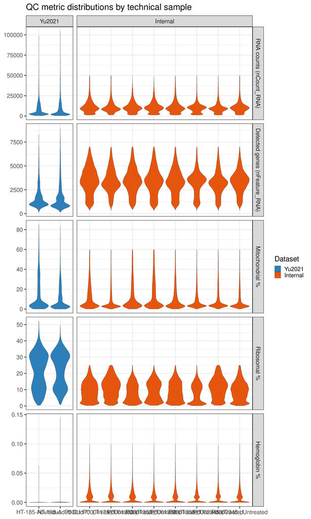

```r
p_qc_violin <- ggplot(
  qc_long,
  aes(x = qc_sample_group, y = value, fill = dataset)
) +
  geom_violin(scale = "width", trim = TRUE, linewidth = 0.2) +
  facet_grid(metric ~ dataset, scales = "free", space = "free_x") +
  scale_fill_manual(values = dataset_palette) +
  labs(
    title = "QC metric distributions by technical sample",
    x = NULL, y = NULL, fill = "Dataset"
  ) +
  theme_qc() +
  theme(
    axis.text.x = element_text(angle = 90, hjust = 1, vjust = 0.5, size = 6),
    legend.position = "none"
  ) +
theme_bw(base_size = 20)

print(p_qc_violin)
```

## 4.1 QC scatter: counts vs. detected genes

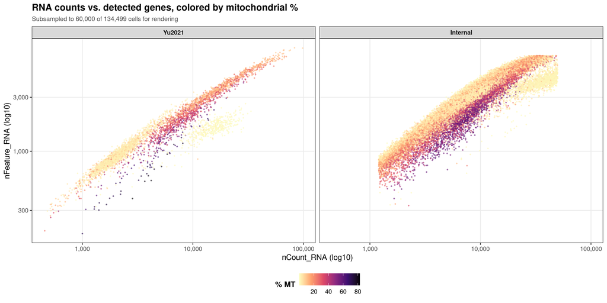

```r
qc_scatter_df <- meta %>%
  slice_sample(n = min(nrow(meta), 60000))  # subsample for rendering speed

p_qc_scatter <- ggplot(
  qc_scatter_df,
  aes(x = nCount_RNA, y = nFeature_RNA, color = percent.mt)
) +
  geom_point(size = 0.4, alpha = 0.5) +
  scale_x_log10(labels = comma) +
  scale_y_log10(labels = comma) +
  scale_color_viridis_c(option = "magma", direction = -1) +
  facet_wrap(~dataset) +
  labs(
    title = "RNA counts vs. detected genes, colored by mitochondrial %",
    subtitle = if (nrow(meta) > nrow(qc_scatter_df))
      paste0("Subsampled to ", comma(nrow(qc_scatter_df)), " of ",
             comma(nrow(meta)), " cells for rendering") else NULL,
    x = "nCount_RNA (log10)", y = "nFeature_RNA (log10)", color = "% MT"
  ) +
  theme_qc()

print(p_qc_scatter)
```

## 4.2 Sample-level QC summary table

Grouped by `qc_sample_group` (subject × condition for Internal; sample for Yu2021). The underlying GEX lane (`technical_sample`) is retained as a column for reference.

```r
qc_sample_summary <- meta %>%
  group_by(dataset, qc_sample_group, biological_subject, condition_common) %>%
  summarise(
    technical_samples    = paste(sort(unique(technical_sample)), collapse = ", "),
    n_cells              = n(),
    median_nCount_RNA    = median(nCount_RNA, na.rm = TRUE),
    median_nFeature_RNA  = median(nFeature_RNA, na.rm = TRUE),
    median_percent_mt    = round(median(percent.mt, na.rm = TRUE), 2),
    median_percent_ribo  = round(median(percent.ribo, na.rm = TRUE), 2),
    median_percent_hb    = round(median(percent.hb, na.rm = TRUE), 2),
    pct_cells_high_mt    = round(100 * mean(percent.mt > params$mt_threshold, na.rm = TRUE), 2),
    .groups = "drop"
  ) %>%
  arrange(dataset, qc_sample_group)

dt_table(qc_sample_summary)
```

| dataset | qc_sample_group | biological_subject | condition_common | technical_samples | n_cells | median_nCount_RNA | median_nFeature_RNA | median_percent_mt | median_percent_ribo | median_percent_hb | pct_cells_high_mt |
| --- | --- | --- | --- | --- | --- | --- | --- | --- | --- | --- | --- |
| Yu2021 | HT-185-Adult-duo | D157 | Healthy | HT-185-Adult-duo | 5043 | 4480 | 1289 | 5.16 | 22.58 | 0 | 28.99 |
| Yu2021 | HT-188-Adult-Duo | D158 | Healthy | HT-188-Adult-Duo | 4745 | 4016 | 1329 | 4.12 | 23.87 | 0 | 20.82 |
| Internal | P0001171 \| Treated | P0001171 | Treated | 23-301-3_GEX2, 23-301-3_GEX4, 23-301-3_GEX6 | 14640 | 10300.5 | 3486 | 7.45 | 9.29 | 0.01 | 24.32 |
| Internal | P0001171 \| Untreated | P0001171 | Untreated | 23-301-3_GEX1, 23-301-3_GEX3, 23-301-3_GEX5 | 26783 | 9603 | 3287 | 3.84 | 11.42 | 0.01 | 16.18 |
| Internal | P0001352 \| Treated | P0001352 | Treated | 23-301-3_GEX2, 23-301-3_GEX4, 23-301-3_GEX6 | 9774 | 10195.5 | 3402.5 | 6.5 | 7.99 | 0.01 | 25.39 |
| Internal | P0001352 \| Untreated | P0001352 | Untreated | 23-301-3_GEX1, 23-301-3_GEX3, 23-301-3_GEX5 | 10084 | 10209.5 | 3376.5 | 7.31 | 9.33 | 0.01 | 29.97 |
| Internal | P0001358 \| Treated | P0001358 | Treated | 23-301-3_GEX1, 23-301-3_GEX3, 23-301-3_GEX5 | 10136 | 9727.5 | 3329 | 5.89 | 8.58 | 0.01 | 19.82 |
| Internal | P0001358 \| Untreated | P0001358 | Untreated | 23-301-3_GEX2, 23-301-3_GEX4, 23-301-3_GEX6 | 15887 | 9922 | 3396 | 4.79 | 8.77 | 0.01 | 14.85 |
| Internal | P0002345 \| Treated | P0002345 | Treated | 23-301-3_GEX1, 23-301-3_GEX3, 23-301-3_GEX5 | 15737 | 9084 | 3177 | 4.59 | 11.34 | 0.01 | 17.35 |
| Internal | P0002345 \| Untreated | P0002345 | Untreated | 23-301-3_GEX2, 23-301-3_GEX4, 23-301-3_GEX6 | 21670 | 10171 | 3396 | 4.06 | 9.36 | 0.01 | 15.81 |

# 5 Cell Counts by Sample

Counts by `qc_sample_group` (subject × condition for Internal; sample for Yu2021).

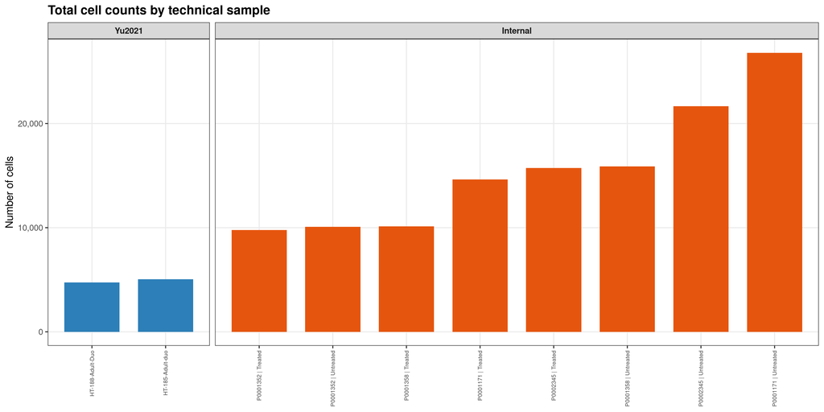

```r
sample_counts <- meta %>%
  count(dataset, qc_sample_group, name = "n_cells")

p_cell_counts <- ggplot(
  sample_counts,
  aes(x = reorder(qc_sample_group, n_cells), y = n_cells, fill = dataset)
) +
  geom_col(width = 0.75) +
  facet_grid(. ~ dataset, scales = "free_x", space = "free_x") +
  scale_fill_manual(values = dataset_palette) +
  scale_y_continuous(labels = comma) +
  labs(
    title = "Total cell counts by technical sample",
    x = NULL, y = "Number of cells", fill = "Dataset"
  ) +
  theme_qc() +
  theme(
    axis.text.x = element_text(angle = 90, hjust = 1, vjust = 0.5, size = 6),
    legend.position = "none"
  )

print(p_cell_counts)
```

# 6 Cell Type Composition by Sample

Composition by `qc_sample_group` (subject × condition for Internal; sample for Yu2021).

## 6.1 Raw counts

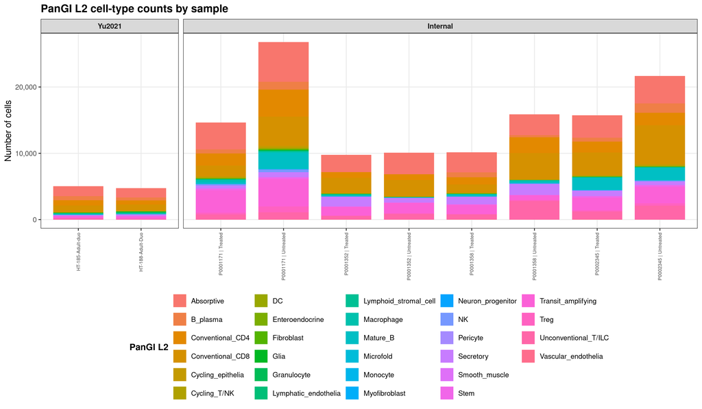

```r
celltype_sample_counts <- meta %>%
  filter(!is.na(celltype_L2_common), celltype_L2_common != "") %>%
  count(dataset, qc_sample_group, celltype_L2_common, name = "n_cells") %>%
  group_by(dataset, qc_sample_group) %>%
  mutate(proportion = n_cells / sum(n_cells)) %>%
  ungroup()

p_celltype_counts <- ggplot(
  celltype_sample_counts,
  aes(x = qc_sample_group, y = n_cells, fill = celltype_L2_common)
) +
  geom_col(width = 0.8) +
  facet_grid(. ~ dataset, scales = "free_x", space = "free_x") +
  scale_y_continuous(labels = comma) +
  labs(
    title = "PanGI L2 cell-type counts by sample",
    x = NULL, y = "Number of cells", fill = "PanGI L2"
  ) +
  theme_qc() +
  theme(axis.text.x = element_text(angle = 90, hjust = 1, vjust = 0.5, size = 6))

print(p_celltype_counts)
```

## 6.2 Proportions

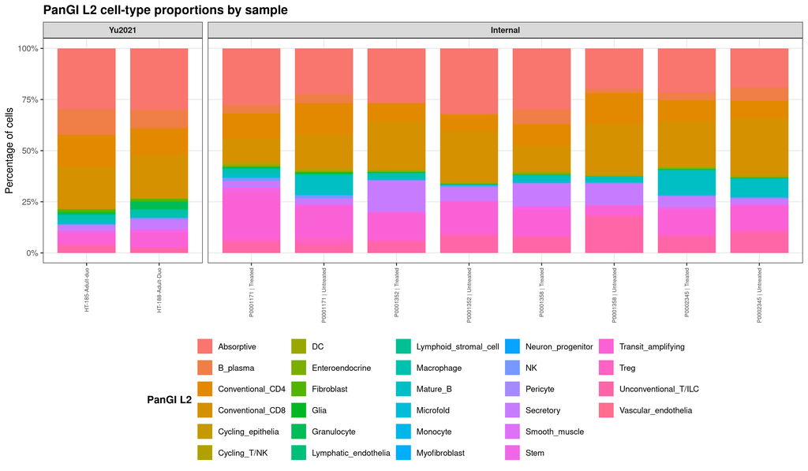

```r
p_celltype_proportions <- ggplot(
  celltype_sample_counts,
  aes(x = qc_sample_group, y = proportion, fill = celltype_L2_common)
) +
  geom_col(width = 0.8) +
  facet_grid(. ~ dataset, scales = "free_x", space = "free_x") +
  scale_y_continuous(labels = percent_format(accuracy = 1)) +
  labs(
    title = "PanGI L2 cell-type proportions by sample",
    x = NULL, y = "Percentage of cells", fill = "PanGI L2"
  ) +
  theme_qc() +
  theme(axis.text.x = element_text(angle = 90, hjust = 1, vjust = 0.5, size = 6))

print(p_celltype_proportions)
```

```r
dt_table(
  celltype_sample_counts %>%
    mutate(percent = round(100 * proportion, 2)) %>%
    select(dataset, qc_sample_group, celltype_L2_common, n_cells, percent) %>%
    arrange(dataset, qc_sample_group, desc(n_cells))
)
```

| dataset | qc_sample_group | celltype_L2_common | n_cells | percent |
| --- | --- | --- | --- | --- |
| Yu2021 | HT-185-Adult-duo | Absorptive | 1495 | 29.65 |
| Yu2021 | HT-185-Adult-duo | Conventional_CD8 | 1036 | 20.54 |
| Yu2021 | HT-185-Adult-duo | Conventional_CD4 | 790 | 15.67 |
| Yu2021 | HT-185-Adult-duo | B_plasma | 633 | 12.55 |
| Yu2021 | HT-185-Adult-duo | Transit_amplifying | 244 | 4.84 |
| Yu2021 | HT-185-Adult-duo | Unconventional_T/ILC | 174 | 3.45 |
| Yu2021 | HT-185-Adult-duo | Secretory | 150 | 2.97 |
| Yu2021 | HT-185-Adult-duo | Macrophage | 118 | 2.34 |
| Yu2021 | HT-185-Adult-duo | Mature_B | 113 | 2.24 |
| Yu2021 | HT-185-Adult-duo | Fibroblast | 71 | 1.41 |

[output cut: 229 more lines]

# 7 UMAP by Dataset: Before vs. After Harmony

Dataset mixing is the primary signal Harmony is correcting for. If integration worked, the “After Harmony” panel should show far more overlap between datasets than “Before”.

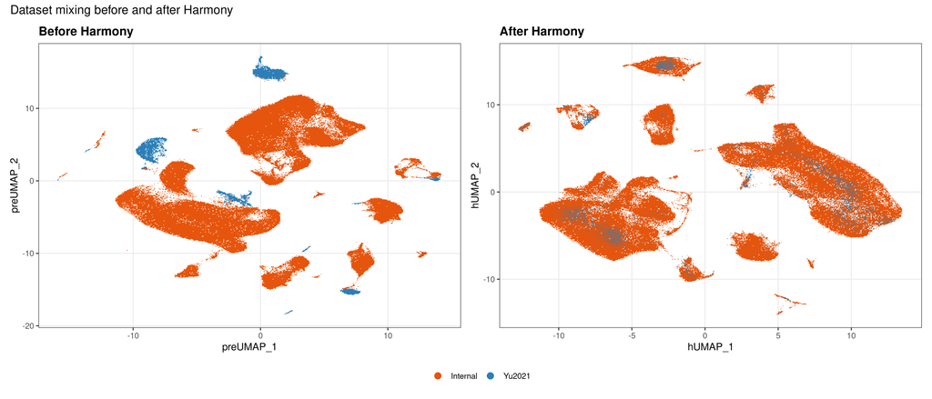

```r
umap_plots <- list()

if (has_pre_harmony) {
  umap_plots$pre <- DimPlot(
    combined, reduction = "umap.preharmony",
    group.by = "dataset", raster = TRUE
  ) +
    scale_color_manual(values = dataset_palette) +
    ggtitle("Before Harmony") +
    theme_qc()
}

if (has_post_harmony) {
  umap_plots$post <- DimPlot(
    combined, reduction = "umap.harmony",
    group.by = "dataset", raster = TRUE
  ) +
    scale_color_manual(values = dataset_palette) +
    ggtitle("After Harmony") +
    theme_qc()
}

if (length(umap_plots) == 2) {
  print(
    (umap_plots$pre | umap_plots$post) +
      plot_layout(guides = "collect") +
      plot_annotation(title = "Dataset mixing before and after Harmony") &
      theme(legend.position = "bottom")
  )
} else if (length(umap_plots) == 1) {
  print(umap_plots[[1]])
} else {
  cat("No UMAP reductions found on the combined object.")
}
```

## 7.1 UMAP colored by PanGI L2, split by dataset (post-Harmony)

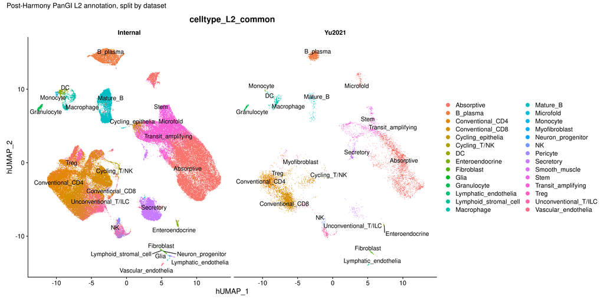

```r
if (has_post_harmony) {
  p_split_dataset <- DimPlot(
    combined,
    reduction = "umap.harmony",
    group.by = "celltype_L2_common",
    split.by = "dataset",
    label = TRUE,
    repel = TRUE,
    raster = TRUE,
    ncol = 2
  ) +
    plot_annotation(title = "Post-Harmony PanGI L2 annotation, split by dataset")

  print(p_split_dataset)
} else {
  cat("Post-Harmony UMAP not available.")
}
```

# 8 UMAP by Sample: Before vs. After Harmony

This section intentionally uses `technical_sample` (the pooled GEX lane for Internal, the sequencing sample for Yu2021) rather than `qc_sample_group`, since the question here is technical/lane-level mixing — the thing Harmony’s neighbor graph actually sees — not the biological subject × condition grouping used for the QC and composition plots above.

## 8.1 Quick mixing check (single panel, colored by sample)

Useful for spotting individual samples that fail to mix even after dataset-level correction (e.g. a batch-specific outlier sample).

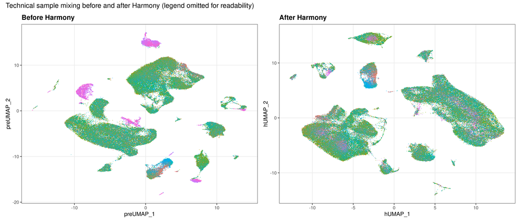

```r
sample_quick_plots <- list()

if (has_pre_harmony) {
  sample_quick_plots$pre <- DimPlot(
    combined, reduction = "umap.preharmony",
    group.by = "technical_sample", raster = TRUE
  ) +
    ggtitle("Before Harmony") +
    theme_qc() +
    theme(legend.position = "none")
}

if (has_post_harmony) {
  sample_quick_plots$post <- DimPlot(
    combined, reduction = "umap.harmony",
    group.by = "technical_sample", raster = TRUE
  ) +
    ggtitle("After Harmony") +
    theme_qc() +
    theme(legend.position = "none")
}

if (length(sample_quick_plots) == 2) {
  print(
    (sample_quick_plots$pre | sample_quick_plots$post) +
      plot_annotation(title = "Technical sample mixing before and after Harmony (legend omitted for readability)")
  )
} else if (length(sample_quick_plots) == 1) {
  print(sample_quick_plots[[1]])
}
```

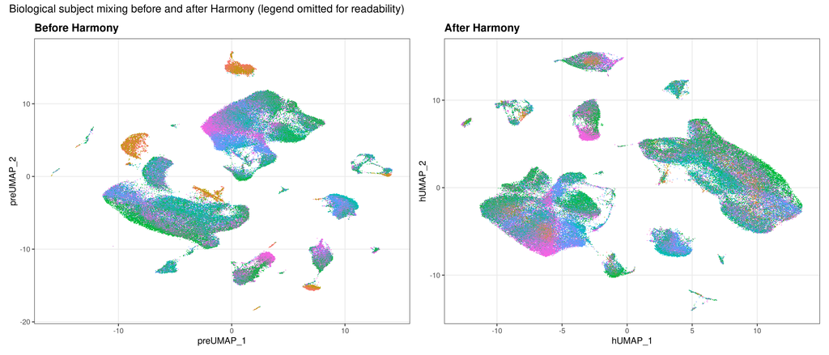

```r
subj_cond_quick_plots <- list()

if (has_pre_harmony) {
  subj_cond_quick_plots$pre <- DimPlot(
    combined, reduction = "umap.preharmony",
    group.by = "biological_subject", raster = TRUE
  ) +
    ggtitle("Before Harmony") +
    theme_qc() +
    theme(legend.position = "none")
}

if (has_post_harmony) {
  subj_cond_quick_plots$post <- DimPlot(
    combined, reduction = "umap.harmony",
    group.by = "biological_subject", raster = TRUE
  ) +
    ggtitle("After Harmony") +
    theme_qc() +
    theme(legend.position = "none")
}

if (length(subj_cond_quick_plots) == 2) {
  print(
    (subj_cond_quick_plots$pre | subj_cond_quick_plots$post) +
      plot_annotation(title = "Biological subject mixing before and after Harmony (legend omitted for readability)")
  )
} else if (length(subj_cond_quick_plots) == 1) {
  print(subj_cond_quick_plots[[1]])
}
```

## 8.3 Full panel view: PanGI L2 split by sample

One panel per technical sample, colored by cell type. This is the most granular view for spotting samples with abnormal or missing cell-type populations.

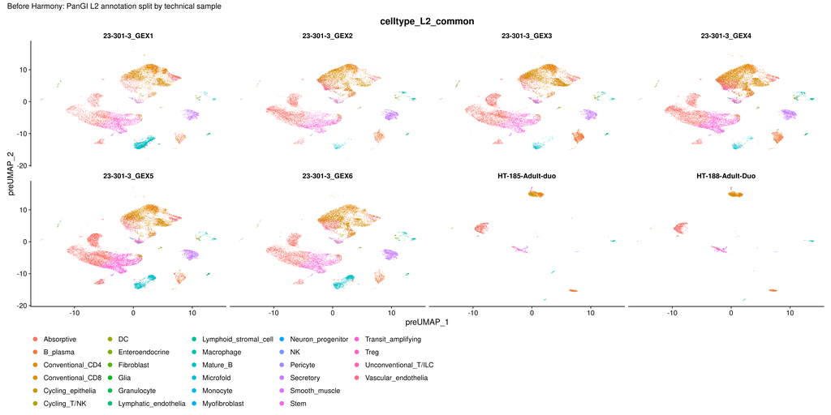

```r
if (has_pre_harmony) {
  p_split_sample_pre <- DimPlot(
    combined,
    reduction = "umap.preharmony",
    group.by = "celltype_L2_common",
    split.by = "technical_sample",
    label = FALSE,
    raster = TRUE,
    ncol = 4
  ) +
    plot_annotation(title = "Before Harmony: PanGI L2 annotation split by technical sample") &
    theme(legend.position = "bottom")

  print(p_split_sample_pre)
} else {
  cat("Pre-Harmony UMAP not available.")
}
```

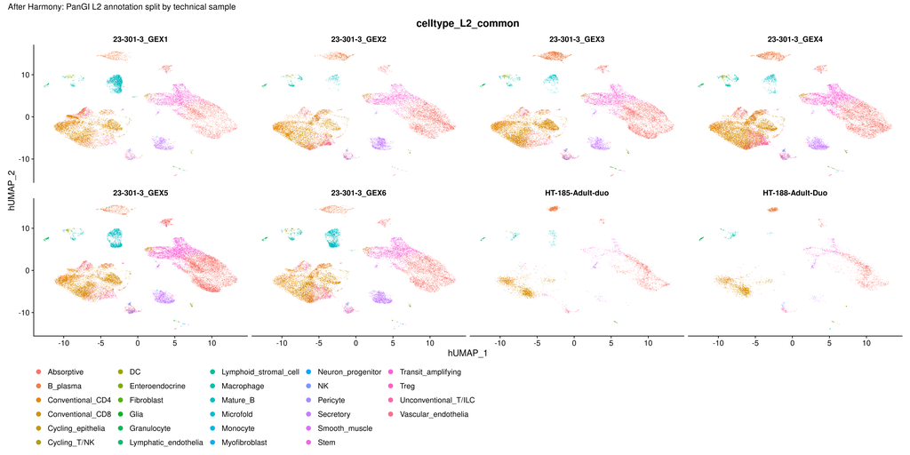

```r
if (has_post_harmony) {
  p_split_sample_post <- DimPlot(
    combined,
    reduction = "umap.harmony",
    group.by = "celltype_L2_common",
    split.by = "technical_sample",
    label = FALSE,
    raster = TRUE,
    ncol = 4
  ) +
    plot_annotation(title = "After Harmony: PanGI L2 annotation split by technical sample") &
    theme(legend.position = "bottom")

  print(p_split_sample_post)
} else {
  cat("Post-Harmony UMAP not available.")
}
```

# 9 Cluster Purity: Dataset Composition per Harmony Cluster

A residual-batch-effect check that isn’t in the source scripts but is standard QC after any integration: for each post-Harmony cluster, what fraction of its cells come from each dataset? Clusters that are almost entirely one dataset (rather than reflecting the overall dataset balance) may indicate incomplete correction or a genuinely dataset-specific cell state — worth inspecting either way.

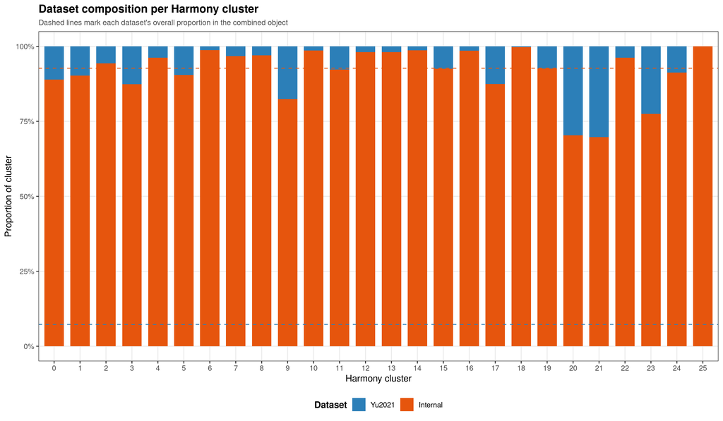

| harmony_cluster | dataset | n_cells | percent |
| --- | --- | --- | --- |
| 0 | Yu2021 | 1927 | 11.09 |
| 0 | Internal | 15452 | 88.91 |
| 1 | Yu2021 | 1278 | 9.77 |
| 1 | Internal | 11798 | 90.23 |
| 2 | Yu2021 | 573 | 5.69 |
| 2 | Internal | 9500 | 94.31 |
| 3 | Yu2021 | 1242 | 12.64 |
| 3 | Internal | 8586 | 87.36 |
| 4 | Yu2021 | 336 | 3.78 |
| 4 | Internal | 8547 | 96.22 |

[output cut: 41 more lines]

```r
if (has_clusters) {
  cluster_dataset_composition <- meta %>%
    count(harmony_cluster, dataset, name = "n_cells") %>%
    group_by(harmony_cluster) %>%
    mutate(proportion = n_cells / sum(n_cells)) %>%
    ungroup()

  overall_dataset_fraction <- meta %>%
    count(dataset) %>%
    mutate(overall_fraction = n / sum(n))

  p_cluster_purity <- ggplot(
    cluster_dataset_composition,
    aes(x = factor(harmony_cluster), y = proportion, fill = dataset)
  ) +
    geom_col(width = 0.75) +
    geom_hline(
      data = overall_dataset_fraction,
      aes(yintercept = overall_fraction, color = dataset),
      linetype = "dashed", linewidth = 0.5, show.legend = FALSE
    ) +
    scale_fill_manual(values = dataset_palette) +
    scale_color_manual(values = dataset_palette) +
    scale_y_continuous(labels = percent_format(accuracy = 1)) +
    labs(
      title = "Dataset composition per Harmony cluster",
      subtitle = "Dashed lines mark each dataset's overall proportion in the combined object",
      x = "Harmony cluster", y = "Proportion of cluster", fill = "Dataset"
    ) +
    theme_qc()

  print(p_cluster_purity)

  dt_table(
    cluster_dataset_composition %>%
      mutate(percent = round(100 * proportion, 2)) %>%
      select(harmony_cluster, dataset, n_cells, percent) %>%
      arrange(harmony_cluster, dataset)
  )
} else {
  cat("`harmony_cluster` column not found on the combined object — skipping cluster purity check.")
}
```